# ANOVA in R

## One-way ANOVA - used when 1 factor > 1 dependent variable

ANOVA or ANalysis Of VAriance is used to measure statistical differences in means.

```r
attach(InsectSprays)
data(InsectSprays)
str(InsectSprays)
```

```
'data.frame':   72 obs. of  2 variables:
 $ count: num  10 7 20 14 14 12 10 23 17 20 ...
 $ spray: Factor w/ 6 levels "A","B","C","D",..: 1 1 1 1 1 1 1 1 1 1 ...
```

spray = 6 categories

```r
oneway.test(count~spray)
```

```
    One-way analysis of means (not assuming equal variances)

data:  count and spray
F = 36.065, num df = 5.000, denom df = 30.043, p-value = 7.999e-12
```

By default, it is assumed that variances are not equal. Use ‘var.equal=TRUE’ to assume equal variance. df = num of categories - 1

Now ANOVA using aov

```r
AOV_Output <- aov(count ~ spray, data=InsectSprays)
summary(AOV_Output)
```

```
            Df Sum Sq Mean Sq F value Pr(>F)
spray        5   2669   533.8    34.7 <2e-16 ***
Residuals   66   1015    15.4
---
Signif. codes:  0 ‘***’ 0.001 ‘**’ 0.01 ‘*’ 0.05 ‘.’ 0.1 ‘ ’ 1
```

## Two-way ANOVA - used when two factors > 1 dependent variable

#### Using lm

Syntax: lm(target_var ~ FactorA + FactorB) #Assuming no interaction between FactorA and B lm(target_var ~ FactorA + FactorB + FactorA*FactorB) #Interaction present

#### using aov

aov(Y ~ A + B, data=d) #only assess main effect (no interaction) aov(Y ~ A * B, data=d) or aov(Y ~ A + B + A:B, data=d) #assess main effect and interactions aov(Y ~ A/B, data=d) or aov(Y ~ A + A:B, data=d) or aov(Y ~ A + B %in% A, data=d) #assume B is nested in A

Sample:

```r
# Create a data frame
data <- data.frame(
  # Dependent variable (replace with your actual data)
  yield = c(50, 42, 55, 48, 62, 54, 45, 38, 58, 50, 34, 43, 48, 40, 38, 49, 48, 39, 48, 38,
            65, 59, 72, 68, 70, 62, 50, 45, 60, 55, 58, 59, 54, 53, 55, 55, 58, 53, 49, 39),

  # Factor 1 (replace with your factor levels)
  fertilizer = c(rep("A", 20), rep("B", 20)),

  # Factor 2 (replace with your factor levels)
  watering = c(rep("Low", 10), rep("High", 10), rep("Low", 10), rep("High", 10))
)

# Perform the ANOVA
model <- aov(yield ~ fertilizer * watering, data = data)

# Get the ANOVA table
summary(model)
```

```
                    Df Sum Sq Mean Sq F value  Pr(>F)
fertilizer           1 1123.6  1123.6  23.239 2.6e-05 ***
watering             1  562.5   562.5  11.634 0.00161 **
fertilizer:watering  1    0.4     0.4   0.008 0.92803
Residuals           36 1740.6    48.3
---
Signif. codes:  0 ‘***’ 0.001 ‘**’ 0.01 ‘*’ 0.05 ‘.’ 0.1 ‘ ’ 1
```

We can see from the p-value that fertilizer and watering types have significant differences. The interaction variable not so much.

We can also calculate the F-quantile and compare the F-statistic to see if there is significance. If F-statistic is higher than the F-quantile then the null hypothesis is rejected.

```r
# Define the significance level (alpha)
alpha <- 0.05  # Example: 5% significance level

# Define the numerator degrees of freedom (df_num)
df_num <- 1  # Example: 1 (numerator degrees of freedom for the F-test)

# Define the denominator degrees of freedom (df_denom)
# For a two-way ANOVA, this would be the residual degrees of freedom
df_denom <- 16  # Example: 16 (residual degrees of freedom)

# Calculate the F quantile
f_quantile <- qf(1 - alpha, df_num, df_denom)

# Print the F quantile
print(f_quantile)
```

```
[1] 4.493998
```

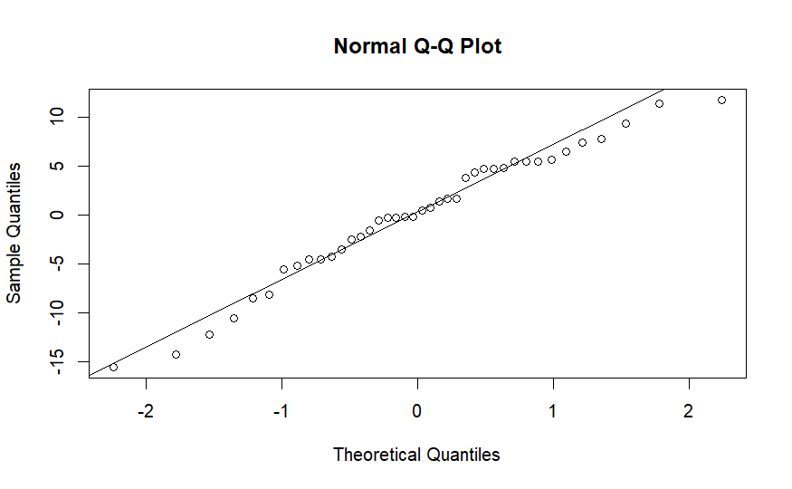

```r
# Extract the residuals from the ANOVA model
residuals <- residuals(model)

# Create a QQ plot for the residuals
qqnorm(residuals)
qqline(residuals)
```

The plots are very close to the central diagonal line suggesting normality.